# GBR mortality prediction uncertainty and extrapolation contract

Cross-fitted intervals, severe-event guardrails, and 2024 environmental support

# Decision

The pipeline now distinguishes four things that should not be collapsed into a single confidence band:

1. posterior uncertainty in the BRMS expected response;
2. disagreement between BRMS and BRT;
3. held-out residual/process error in the selected programme route; and
4. environmental and community-input support at the prediction location.

The saved BRMS Q05–Q95 limits came from `posterior_epred`; they are intervals for expected mortality, not observation-level prediction intervals. Cross- fitted residual intervals are therefore the current predictive uncertainty layer. Even these remain marginal: their severe-event coverage is reported separately and cannot be inferred from overall coverage.

A full GBR mortality surface is **not released yet**. Every 2024 registry row lacks a complete, audited pre-event community layer for the model predictors `prop_acropora_pre` and `acropora_cover_pre`; MMP additionally requires depth. Environmental support maps below are diagnostics, not mortality maps.

# Expected-response intervals are too narrow

Empirical coverage of nominal BRMS 90% intervals for expected mortality. These are not posterior predictive intervals.

| Programme | Assessment | n | All-row coverage | severe_n | Severe-row coverage | Mean width |
| --- | --- | --- | --- | --- | --- | --- |
| LTMP benthic | Leave one event out | 199 | 29.6% | 29 | 62.1% | 0.212 |
| LTMP benthic | Reef blocked | 199 | 24.6% | 29 | 37.9% | 0.136 |
| LTMP manta tow | Leave one event out | 248 | 24.6% | 56 | 37.5% | 0.222 |
| LTMP manta tow | Reef blocked | 248 | 20.6% | 56 | 32.1% | 0.139 |
| MMP inshore | Leave one event out | 90 | 54.4% | 35 | 74.3% | 0.588 |
| MMP inshore | Reef blocked | 90 | 40.0% | 35 | 57.1% | 0.314 |

Low coverage is expected when parameter uncertainty is presented as if it also contained observation noise, unmeasured event mechanisms, and model-form error. Renaming these limits is not cosmetic; it prevents overconfident maps.

# Cross-fitted predictive intervals

For each outer assessment fold, the interval radius is the finite-sample 90th percentile of absolute residuals from *other* outer folds of the same programme and validation scheme. No assessment outcome calibrates its own interval.

The severe upper guardrail is calibrated the same way using only mortality of at least 20% in the other folds. It is intentionally conservative and should be shown as a high-loss risk bound, not as another central interval.

Event-held-out uncertainty performance

| Programme | Subgroup | n | Marginal coverage | Severe upper guard coverage | Mean interval width | Mean BRMS-BRT disagreement |
| --- | --- | --- | --- | --- | --- | --- |
| LTMP benthic | All observations | 199 | 89.9% | 99.0% | 0.288 | 0.054 |
| LTMP manta tow | All observations | 248 | 83.5% | 98.0% | 0.287 | 0.058 |
| MMP inshore | All observations | 90 | 81.1% | 81.1% | 0.458 | 0.032 |
| LTMP benthic | Positive mortality | 87 | 79.3% | 97.7% | 0.293 | 0.071 |
| LTMP manta tow | Positive mortality | 110 | 64.5% | 95.5% | 0.274 | 0.062 |
| MMP inshore | Positive mortality | 59 | 71.2% | 71.2% | 0.461 | 0.034 |
| LTMP benthic | Mortality >= 20% | 29 | 44.8% | 93.1% | 0.330 | 0.113 |
| LTMP manta tow | Mortality >= 20% | 56 | 37.5% | 91.1% | 0.271 | 0.080 |
| MMP inshore | Mortality >= 20% | 35 | 51.4% | 51.4% | 0.421 | 0.033 |

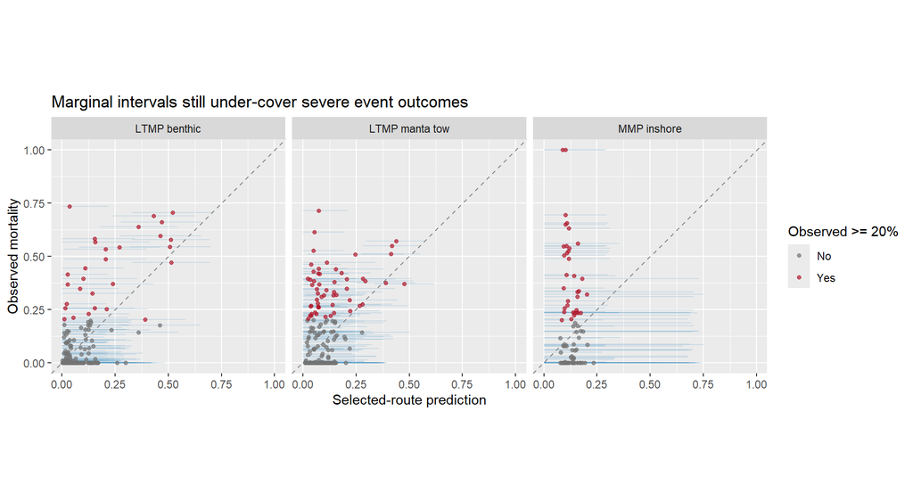

# Framework disagreement

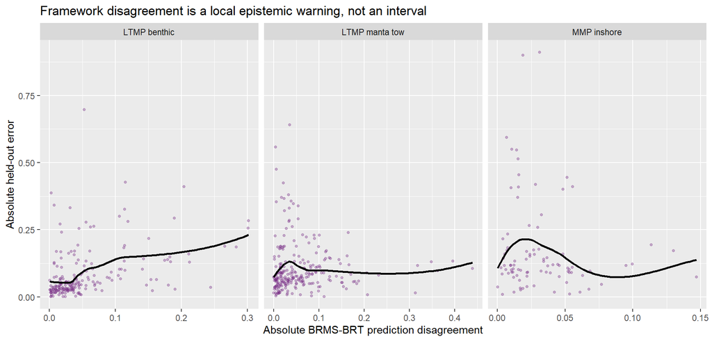

Disagreement should accompany future prediction rows, but it is not a complete uncertainty measure: learners can agree and still share the same missing event mechanism.

# 2024 environmental support

Environmental support uses the 15 predictors available consistently in the full registry. For each programme, values are standardised with its formal training rows. A nearest-training-row distance is compared with leave-one-row- out 95th and 99th percentiles, while individual predictors are also checked against training ranges.

| Programme | Environmental support | Features | Percent |
| --- | --- | --- | --- |
| LTMP benthic | caution | 1977 | 28.0% |
| LTMP benthic | extreme extrapolation | 2912 | 41.2% |
| LTMP benthic | missing environmental input | 37 | 0.5% |
| LTMP benthic | within environmental support | 2137 | 30.3% |
| LTMP manta tow | caution | 1363 | 19.3% |
| LTMP manta tow | extreme extrapolation | 3973 | 56.3% |
| LTMP manta tow | missing environmental input | 37 | 0.5% |
| LTMP manta tow | within environmental support | 1690 | 23.9% |
| MMP inshore | extreme extrapolation | 7008 | 99.2% |
| MMP inshore | missing environmental input | 37 | 0.5% |
| MMP inshore | within environmental support | 18 | 0.3% |

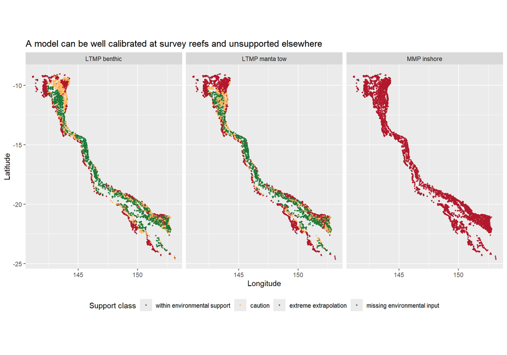

MMP is an inshore programme with a narrow environmental training domain; only 18 of 7,063 registry features lie within its environmental support. MMP should therefore not be extrapolated as a general GBR-wide surface. It is a distinct inshore prediction target.

Largest univariate support gaps in the 2024 registry

| Programme | Predictor | Outside training range | Missing features | Training minimum | Training maximum |
| --- | --- | --- | --- | --- | --- |
| LTMP benthic | winyear_sd | 2430 | 30 | 1.463 | 2.644 |
| LTMP benthic | dist_to_er_km | 1257 | 0 | 0.172 | 2.026 |
| LTMP benthic | mcur_90 | 635 | 0 | 0.131 | 0.649 |
| LTMP benthic | secc3m | 481 | 7 | 7.654 | 36.496 |
| LTMP benthic | secc3m_p10 | 476 | 7 | 6.584 | 28.146 |
| LTMP manta tow | winyear_sd | 2889 | 30 | 1.463 | 2.387 |
| LTMP manta tow | winyear_mean | 1721 | 30 | 24.272 | 27.710 |
| LTMP manta tow | dist_to_er_km | 1142 | 0 | 0.172 | 2.128 |
| LTMP manta tow | mcur_90 | 635 | 0 | 0.131 | 0.649 |
| LTMP manta tow | secc3m | 481 | 7 | 7.654 | 36.496 |
| MMP inshore | winyear_sd | 5434 | 30 | 1.852 | 2.835 |
| MMP inshore | winyear_mean | 3834 | 30 | 24.323 | 27.286 |
| MMP inshore | ann_maxdhw | 2417 | 30 | 4.120 | 13.260 |
| MMP inshore | dhw_novelty10 | 1212 | 30 | -4.720 | 9.240 |
| MMP inshore | secc3m_p10 | 1129 | 7 | 2.512 | 17.123 |

# Production contract

Before a reef-level prediction is publishable, it must carry:

- the BRMS and BRT component predictions and their absolute disagreement;
- the selected programme route and fixed cross-fitted production weights;
- a cross-calibrated marginal interval and severe-event upper guardrail;
- environmental support class and the predictors outside training range;
- provenance and uncertainty for interpolated pre-event Acropora and total coral cover, plus depth for MMP; and
- a suppression flag when required inputs are missing or the target is outside the intended programme domain.

The immediate implementation gap is the full-registry community layer. The old Acropora interpolation supplies a proportion but does not provide a fully audited, past-only absolute pre-event Acropora cover for all registry features. Using a median community value would produce a clean-looking map while removing one of the most influential ecological predictors. The pipeline therefore stops at environmental support rather than silently making that substitution.